# Bi Weekly assignment:Week 5 -Network analysis and visualization

Shyni David

2/6/2019

##### Import files

```r
library(readr)
library(tidyverse)
```

```r
#install.packages("tidygraph")
library(tidygraph)
#install.packages("ggraph")
library(ggraph)
#install.packages("igraph")
library(igraph)
library(ggplot2)


 setwd("~/Desktop/FISHER SMB-A/Term 3/Descriptive Analytics/Week 5")
nodes <- read_csv("nodes.csv")
edges <- read_csv("edges.csv")
g <- graph_from_data_frame(edges, vertices=nodes, directed=F)

g1 <- as_tbl_graph(g)
g1
```

```
## # A tbl_graph: 128 nodes and 150 edges
## #
## # A bipartite simple graph with 4 components
## #
## # Node Data: 128 x 2 (active)
##   name           type
##   <chr>          <chr>
## 1 Ike Agho       Person
## 2 Megan Appelt   Person
## 3 Brandi Cade    Person
## 4 Sarah Condon   Person
## 5 Ian Cunningham Person
## 6 Shyni David    Person
## # … with 122 more rows
## #
## # Edge Data: 150 x 3
##    from    to weight
##   <int> <int>  <dbl>
## 1     1    31     30
## 2     1    32     25
## 3     1    33     20
## # … with 147 more rows
```

##### Create a node-link diagram differentiating the type of nodes. For example, you can use different colors to denote Person and Dataset. Also, encode edge weights into the visualization. For example, you can use alpha or width to encode edge weights.

```r
as.tibble(g1 %>% activate(edges))
```

```
## # A tibble: 150 x 3
##     from    to weight
##    <int> <int>  <dbl>
##  1     1    31     30
##  2     1    32     25
##  3     1    33     20
##  4     1    34     15
##  5     1    35     10
##  6     2    36     30
##  7     2    37     25
##  8     2    35     20
##  9     2    38     15
## 10     2    39     10
## # … with 140 more rows
```

```
## Using `nicely` as default layout
```

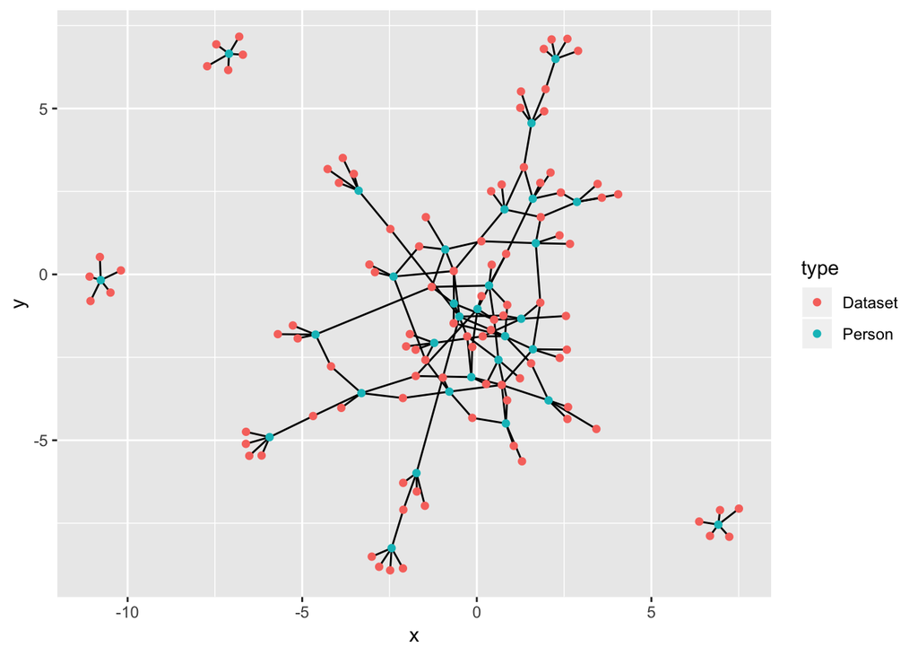

```r
  ggraph(g1) +   geom_edge_link()  + geom_node_point(aes( color=type))
```

```
## Using `nicely` as default layout
```

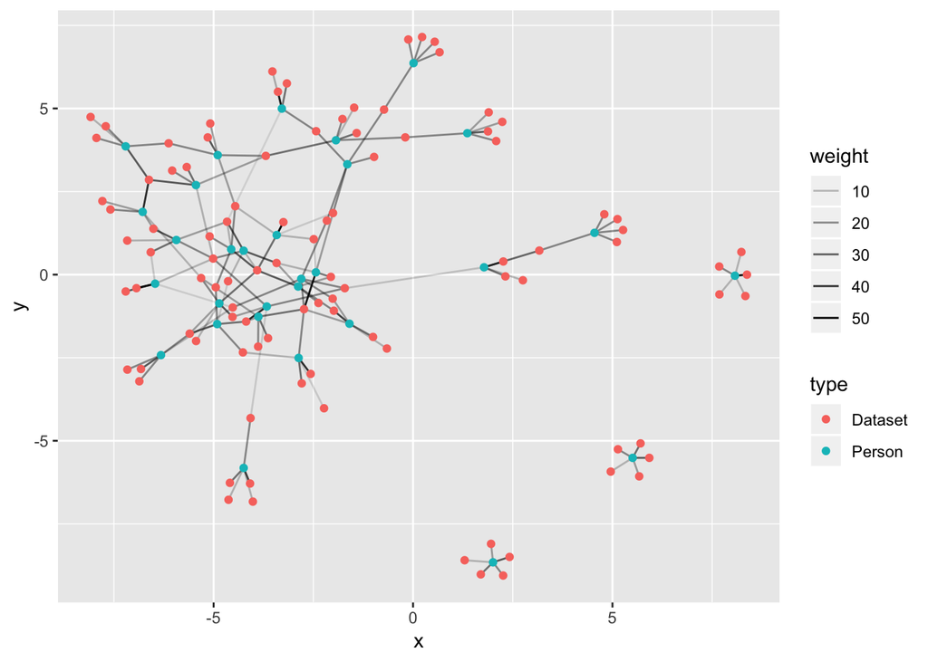

```r
  ggraph(g1) +   geom_edge_link(aes(alpha = weight))  + geom_node_point(aes( color=type))
```

#### Answer: “How many components are there in this network?”

```r
count_components(g1)
```

```
## [1] 4
```

#### Extract the largest component by referring to the following code. The largest component in a graph is called “main component”.

```r
mc <- decompose(g)[[1]]
```

#### Give the names of Person nodes that do not belong to the main component.

```r
mc2 <- decompose(g)[[2]]
mc2
```

```
## IGRAPH d22e286 UNWB 6 5 --
## + attr: name (v/c), type (v/c), weight (e/n)
## + edges from d22e286 (vertex names):
## [1] Sarah Condon--loveall/clicks-conversion-tracking
## [2] Sarah Condon--joniarroba/noshowappointments
## [3] Sarah Condon--c/talkingdata-mobile-user-demographics
## [4] Sarah Condon--bigquery/google-analytics-sample
## [5] Sarah Condon--tockie94/dshomework1
```

```r
mc3 <- decompose(g)[[3]]
mc3
```

```
## IGRAPH 0185e08 UNWB 6 5 --
## + attr: name (v/c), type (v/c), weight (e/n)
## + edges from 0185e08 (vertex names):
## [1] Sophia Lai--koki25ando/hostel-world-dataset
## [2] Sophia Lai--prajitdatta/data-stories-of-us-airlines
## [3] Sophia Lai--new-york-state/nys-retail-food-store-inspections,-current-ratings
## [4] Sophia Lai--datafiniti/hotel-reviews
## [5] Sophia Lai--chicago/chi-restaurant-inspections
```

```r
mc4 <- decompose(g)[[4]]
mc4
```

```
## IGRAPH 899ecf0 UNWB 6 5 --
## + attr: name (v/c), type (v/c), weight (e/n)
## + edges from 899ecf0 (vertex names):
## [1] Brian Stamper--jtrofe/beer-recipes
## [2] Brian Stamper--martinellis/nhl-game-data
## [3] Brian Stamper--usdot/nhtsa-traffic-fatalities
## [4] Brian Stamper--alxmamaev/flowers-recognition
## [5] Brian Stamper--heesoo37/120-years-of-olympic-history-athletes-and-results
```

```r
print("Sarah Condon, Sophia Lai and Brian Stamper do not belong to the main component.")
```

```
## [1] "Sarah Condon, Sophia Lai and Brian Stamper do not belong to the main component."
```

#### Convert the main component as a bipartitle graph into two unipartite (or one-mode) graphs by referring to the following code block.

```r
h <- bipartite_projection(mc, types=V(mc)$type=="Person")
datasets <- h$proj1
persons <- h$proj2
```

#### Visualize both datasets and persons graphs using node-link diagrams.

```
## Using `nicely` as default layout
```

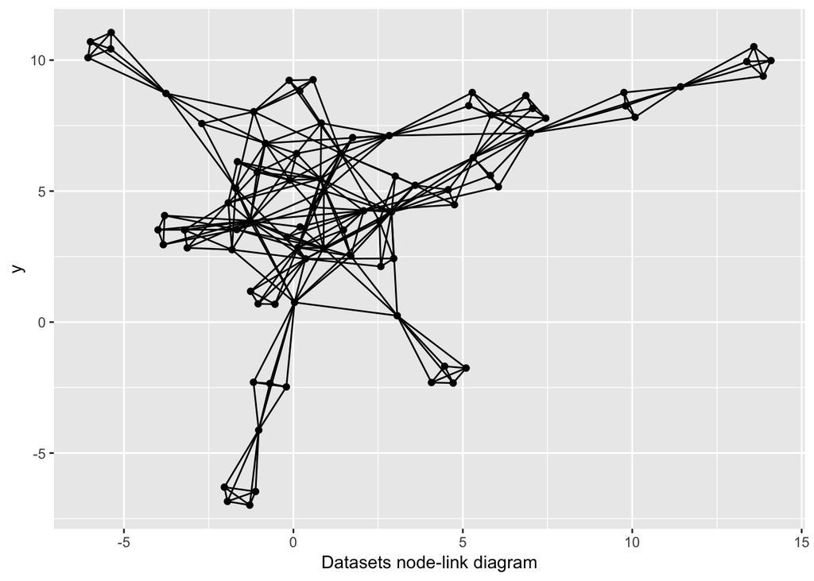

```r
ggraph(datasets) +   geom_edge_link()  + geom_node_point() + xlab("Datasets node-link diagram")
```

```
## Using `nicely` as default layout
```

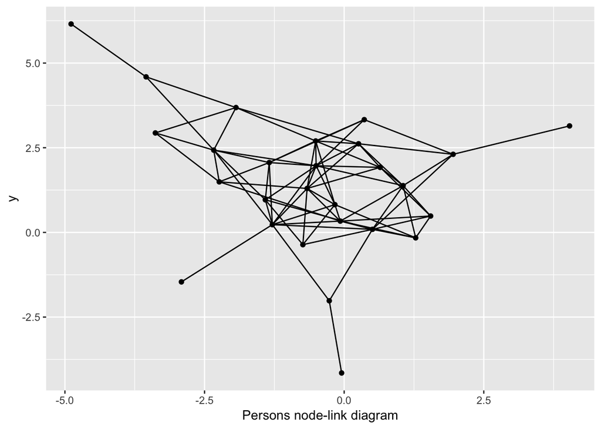

```r
ggraph(persons) +   geom_edge_link()  + geom_node_point() + xlab("Persons node-link diagram")
```

#### Compute closeness centralities for all nodes in the persons graph.

```r
closeness(persons, normalized = TRUE)
```

```
##             Ike Agho         Megan Appelt          Brandi Cade
##            0.5098039            0.4727273            0.5000000
##       Ian Cunningham          Shyni David        Matthew Davis
##            0.4406780            0.2954545            0.5306122
##         Samantha Day        Alex Duquenne           John Ellis
##            0.4727273            0.2795699            0.5531915
##      Matthew Fleming          Kunal Gupta           Matt Hawes
##            0.3132530            0.4561404            0.4262295
##   Kristopher Koloini         Manish Kumar    Danielle Lumbatis
##            0.4727273            0.4727273            0.4482759
##            Josh Mark         Mary McClain      Marianne Morgan
##            0.4193548            0.5098039            0.4905660
##     Tasneem Motiwala          Chris Owens       Jonathan Parry
##            0.3768116            0.4333333            0.4814815
##      David Pickering Shannon Poffenberger           Esther See
##            0.4814815            0.3714286            0.4126984
##          Marek Simon         Aaron Thomas           Alex Webel
##            0.3939394            0.3939394            0.5777778
```

```r
close <- closeness(persons, normalized = TRUE)
```

#### Compute betweenness centralities for all nodes in the persons graph

```r
betweenness(persons, normalized = TRUE)
```

```
##             Ike Agho         Megan Appelt          Brandi Cade
##          0.161341880          0.027810745          0.110088800
##       Ian Cunningham          Shyni David        Matthew Davis
##          0.006559441          0.000000000          0.081251748
##         Samantha Day        Alex Duquenne           John Ellis
##          0.038217338          0.000000000          0.081117882
##      Matthew Fleming          Kunal Gupta           Matt Hawes
##          0.000000000          0.098863248          0.008725719
##   Kristopher Koloini         Manish Kumar    Danielle Lumbatis
##          0.037475635          0.052063714          0.065648352
##            Josh Mark         Mary McClain      Marianne Morgan
##          0.022808747          0.069365523          0.025421245
##     Tasneem Motiwala          Chris Owens       Jonathan Parry
##          0.076923077          0.017692308          0.038981685
##      David Pickering Shannon Poffenberger           Esther See
##          0.063475413          0.000000000          0.076923077
##          Marek Simon         Aaron Thomas           Alex Webel
##          0.002051282          0.008213675          0.217030747
```

```r
betw <- betweenness(persons, normalized = TRUE)
```

##### Report the correlation between the two centrality measures.

```r
cor(close, betw)
```

```
## [1] 0.6818134
```

#### Who has the highest closeness centrality in the persons graph? Hint: Use sort function

```r
 sort(close)
```

```
##        Alex Duquenne          Shyni David      Matthew Fleming
##            0.2795699            0.2954545            0.3132530
## Shannon Poffenberger     Tasneem Motiwala          Marek Simon
##            0.3714286            0.3768116            0.3939394
##         Aaron Thomas           Esther See            Josh Mark
##            0.3939394            0.4126984            0.4193548
##           Matt Hawes          Chris Owens       Ian Cunningham
##            0.4262295            0.4333333            0.4406780
##    Danielle Lumbatis          Kunal Gupta         Megan Appelt
##            0.4482759            0.4561404            0.4727273
##         Samantha Day   Kristopher Koloini         Manish Kumar
##            0.4727273            0.4727273            0.4727273
##       Jonathan Parry      David Pickering      Marianne Morgan
##            0.4814815            0.4814815            0.4905660
##          Brandi Cade             Ike Agho         Mary McClain
##            0.5000000            0.5098039            0.5098039
##        Matthew Davis           John Ellis           Alex Webel
##            0.5306122            0.5531915            0.5777778
```

#### The highest closeness centrality is for Alex Webel.

#### Who has a zero for betweenness centrality in the persons graph? It can be multiple people; name all if that’s the case.

```r
sort(betw)
```

```
##          Shyni David        Alex Duquenne      Matthew Fleming
##          0.000000000          0.000000000          0.000000000
## Shannon Poffenberger          Marek Simon       Ian Cunningham
##          0.000000000          0.002051282          0.006559441
##         Aaron Thomas           Matt Hawes          Chris Owens
##          0.008213675          0.008725719          0.017692308
##            Josh Mark      Marianne Morgan         Megan Appelt
##          0.022808747          0.025421245          0.027810745
##   Kristopher Koloini         Samantha Day       Jonathan Parry
##          0.037475635          0.038217338          0.038981685
##         Manish Kumar      David Pickering    Danielle Lumbatis
##          0.052063714          0.063475413          0.065648352
##         Mary McClain     Tasneem Motiwala           Esther See
##          0.069365523          0.076923077          0.076923077
##           John Ellis        Matthew Davis          Kunal Gupta
##          0.081117882          0.081251748          0.098863248
##          Brandi Cade             Ike Agho           Alex Webel
##          0.110088800          0.161341880          0.217030747
```

#### Shyni David, Alex Duquenne, Matthew Fleming and Shannon Poffenberger has zero betweenness centrality in the person’s graph.

#### What does it mean to have a zero betweeness centrality in this context?

##### Betweenness centrality gives high score to nodes sitting in critical junctions for example node between two highly connected group of nodes. So in persons network, the nodes with zero betweenness are the nodes with single edge, that is a node that is connected to the rest of the network with only one edge.